# Assignment 03: dplyr/ggplot2 Part II

## Task Option 2

*Get the maximum and minimum of GDP per capita for all continents.*

I came up with two possible interpretations of this question. Here are the solutions to each:

1. Maximum and minimum GDP per capita **of all time** achieved in each continent:

### Figure 1

```r
per_cont <- gapminder %>%
  group_by(continent) %>%
  filter(gdpPercap==min(gdpPercap) | gdpPercap==max(gdpPercap)) %>%
  mutate(type=if_else(gdpPercap==max(gdpPercap), paste("max"), paste("min"))) %>%
  arrange(type)

kable(per_cont, caption="Maximum and minimum historical GDP per capita of each continent")
```

Maximum and minimum historical GDP per capita of each continent

| country | continent | year | lifeExp | pop | gdpPercap | type |
| --- | --- | --- | --- | --- | --- | --- |
| Australia | Oceania | 2007 | 81.235 | 20434176 | 34435.3674 | max |
| Kuwait | Asia | 1957 | 58.033 | 212846 | 113523.1329 | max |
| Libya | Africa | 1977 | 57.442 | 2721783 | 21951.2118 | max |
| Norway | Europe | 2007 | 80.196 | 4627926 | 49357.1902 | max |
| United States | Americas | 2007 | 78.242 | 301139947 | 42951.6531 | max |
| Australia | Oceania | 1952 | 69.120 | 8691212 | 10039.5956 | min |
| Bosnia and Herzegovina | Europe | 1952 | 53.820 | 2791000 | 973.5332 | min |
| Congo, Dem. Rep. | Africa | 2002 | 44.966 | 55379852 | 241.1659 | min |
| Haiti | Americas | 2007 | 60.916 | 8502814 | 1201.6372 | min |
| Myanmar | Asia | 1952 | 36.319 | 20092996 | 331.0000 | min |

- Here’s a bar graph edition with a logarithmic y-axis scale.

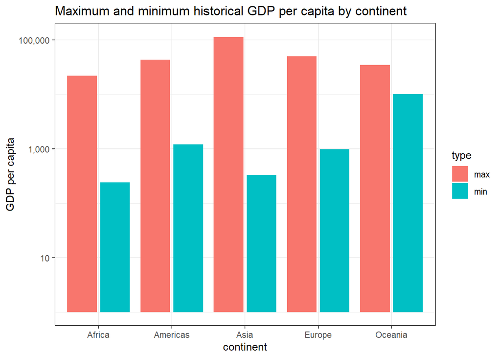

```r
per_cont %>%
  group_by(continent, type) %>%
  ggplot(aes(x=continent, y=gdpPercap)) +
  geom_bar(stat="identity", aes(fill=type), position=position_dodge2()) +
  scale_y_log10(labels=comma_format()) + theme_bw() +
  ggtitle("Maximum and minimum historical GDP per capita by continent") +
  ylab("GDP per capita")
```

- From this plot, we can see that greatest maximum GDP per capita was achieved by Asia, while minimum was Africa. Oceania has the smallest difference between maximum and minimum GDP per capita.
2. We can also take the task request to mean the maximum and minimum GDP per capita achieved in each continent **for a given year**.
- Let’s present all the maximum and minimum GDPs as a box plot so we can see their spread over the years.

### Figure 2

```r
per_cont_year <- gapminder %>%
  group_by(continent, year) %>%
  filter(gdpPercap==min(gdpPercap) | gdpPercap==max(gdpPercap)) %>%
  mutate(type=if_else(gdpPercap==max(gdpPercap), paste("max"), paste("min")), gdpPercap=round(gdpPercap, 2))
datatable(per_cont_year, caption="Maximum and minimum GDP per capita per year")
```

|  | country | continent | year | lifeExp | pop | gdpPercap | type |
| --- | --- | --- | --- | --- | --- | --- | --- |
| 1 | Albania | Europe | 1982 | 70.42 | 2780097 | 3630.88 | min |
| 2 | Albania | Europe | 1987 | 72 | 3075321 | 3738.93 | min |
| 3 | Albania | Europe | 1992 | 71.581 | 3326498 | 2497.44 | min |
| 4 | Albania | Europe | 1997 | 72.95 | 3428038 | 3193.05 | min |
| 5 | Albania | Europe | 2002 | 75.651 | 3508512 | 4604.21 | min |
| 6 | Albania | Europe | 2007 | 76.423 | 3600523 | 5937.03 | min |
| 7 | Australia | Oceania | 1952 | 69.12 | 8691212 | 10039.6 | min |
| 8 | Australia | Oceania | 1957 | 70.33 | 9712569 | 10949.65 | min |
| 9 | Australia | Oceania | 1962 | 70.93 | 10794968 | 12217.23 | min |
| 10 | Australia | Oceania | 1967 | 71.1 | 11872264 | 14526.12 | max |

[output cut: 110 more lines]

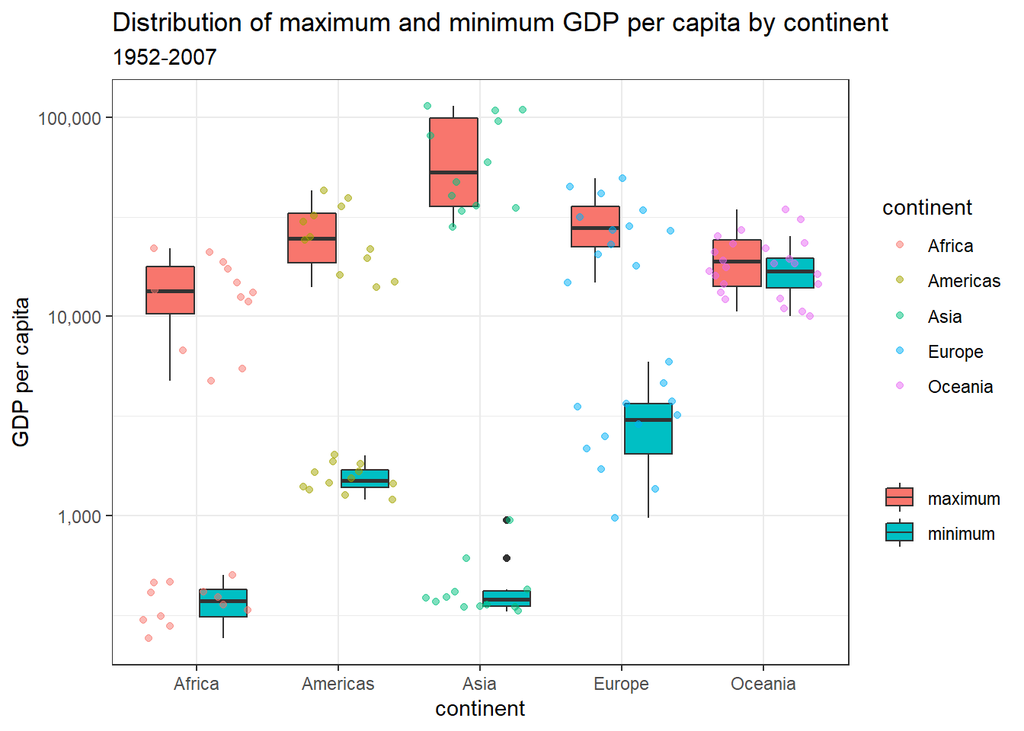

```r
per_cont_year %>%
  ggplot(aes(x=continent, y=gdpPercap)) +
  geom_boxplot(aes(fill=type)) +
  geom_jitter(alpha=0.5, aes(color=continent)) +
  scale_y_log10(labels=comma_format()) + theme_bw() +
  ylab("GDP per capita") + scale_fill_discrete("", labels=c("maximum", "minimum")) +
  ggtitle("Distribution of maximum and minimum GDP per capita by continent", subtitle="1952-2007")
```

- GDP changes for each year will be difficult to show in one clean and easy plot. The ideal situation might be to split the data by year and generate a separate plot for each year, sort of like this:

### Figure 3

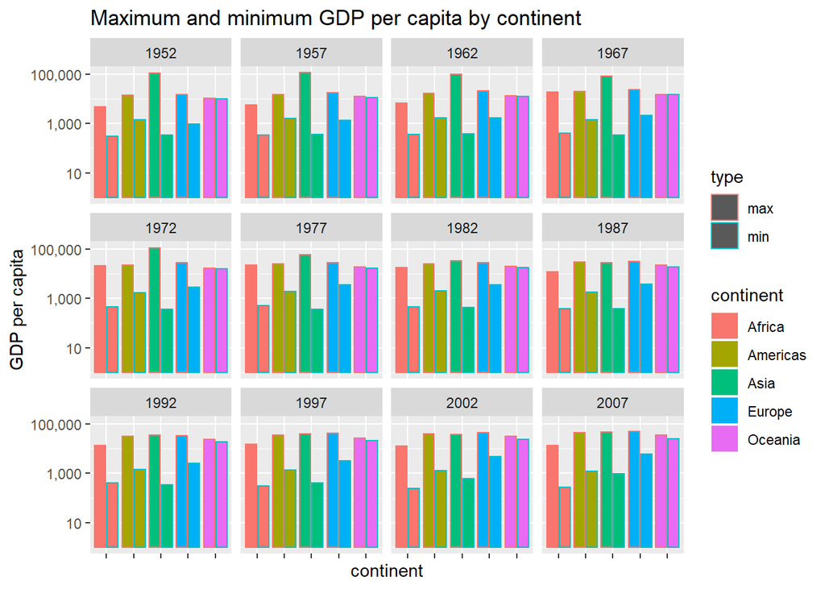

```r
per_cont_year %>%
  ggplot(aes(x=continent, y=gdpPercap, color=type)) +
  geom_bar(stat="identity", position=position_dodge2(), aes(fill=continent)) +
  facet_wrap(~year) +
  scale_y_log10(labels=comma_format()) +
  ylab("GDP per capita") + scale_x_discrete(labels=NULL) +
  ggtitle("Maximum and minimum GDP per capita by continent")
```

- Inferences from this plot:

[output not shown]

Through the analyses above, we can make some general inferences:

- Asia has experienced the greatest fluctuation in GDP per capita, while Oceania has had the least.
- Countries in Africa and Asia are bringing in some of the lowest GDPs per capita, but there are also Asian countries with GDPs on par with the highest earners in Europe and the Americas.
- Asia used to lead in maximum GDP per capita, but the continents have been evening out over the years.

## Task Option 4

*Compute a trimmed mean of life expectancy for different years. Or a weighted mean, weighting by population. Just try something other than the plain vanilla mean.*

I’ll be plotting a weighted mean by population (following up on some plotting I did in the last assignment, where I calculated the mean by country and explained why that type of analysis could be faulty). To get a sense of what we’re working with, here is a graph comparing life expectancy and population:

### Figure 4

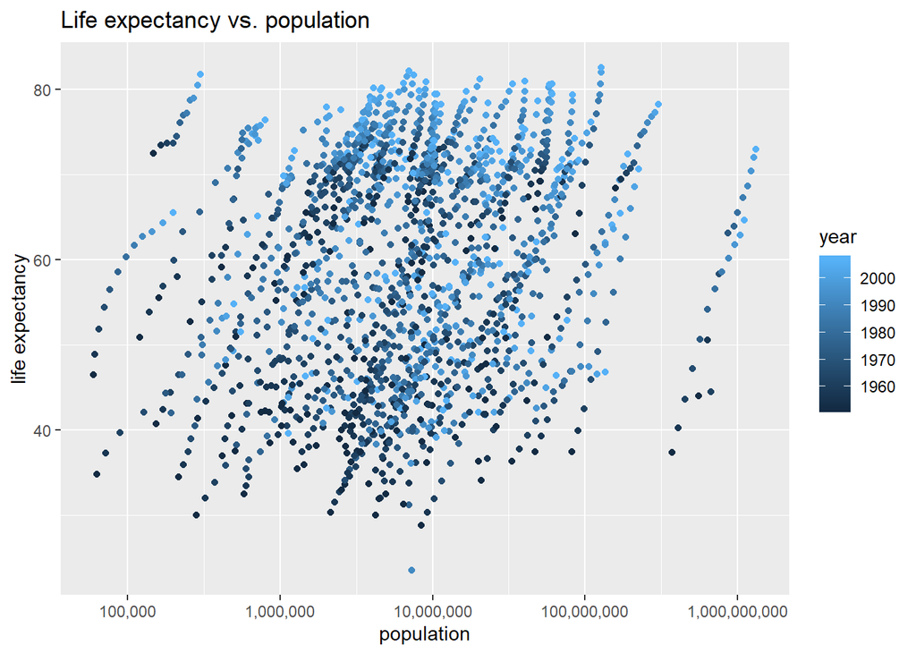

```r
gapminder %>%
  ggplot(aes(x=pop, y=lifeExp, color=year)) +
  geom_point() +
  scale_x_log10(labels=comma_format()) +
  xlab("population") + ylab("life expectancy") +
  ggtitle("Life expectancy vs. population")
```

Over the years, there seems to be a general upward trend in life expectancy and population, roughly following the same exponential increase. But the population of all the countries varies greatly.

Here is mean global life expectancy over the years, weighted by population:

### Figure 5

```r
lifeExp_pop <- gapminder %>%
  group_by(year) %>%
  summarize(global_avg_lifeExp=weighted.mean(lifeExp, pop))

kable(lifeExp_pop, caption="Global life expectancy, weighted by population")
```

Global life expectancy, weighted by population

| year | global_avg_lifeExp |
| --- | --- |
| 1952 | 48.94424 |
| 1957 | 52.12189 |
| 1962 | 52.32438 |
| 1967 | 56.98431 |
| 1972 | 59.51478 |
| 1977 | 61.23726 |
| 1982 | 62.88176 |
| 1987 | 64.41635 |
| 1992 | 65.64590 |
| 1997 | 66.84934 |
| 2002 | 67.83904 |
| 2007 | 68.91909 |

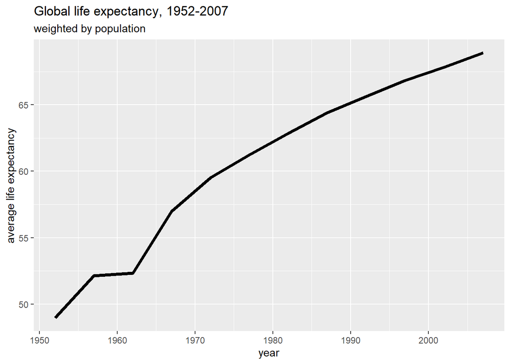

```r
lifeExp_pop %>%
  ggplot(aes(x=year, y=global_avg_lifeExp)) + geom_line(size=1.5) +
  ylab("average life expectancy") +
  ggtitle("Global life expectancy, 1952-2007", subtitle="weighted by population")
```

By contrast, here is a plot of mean global life expectancy weighted by country:

### Figure 6

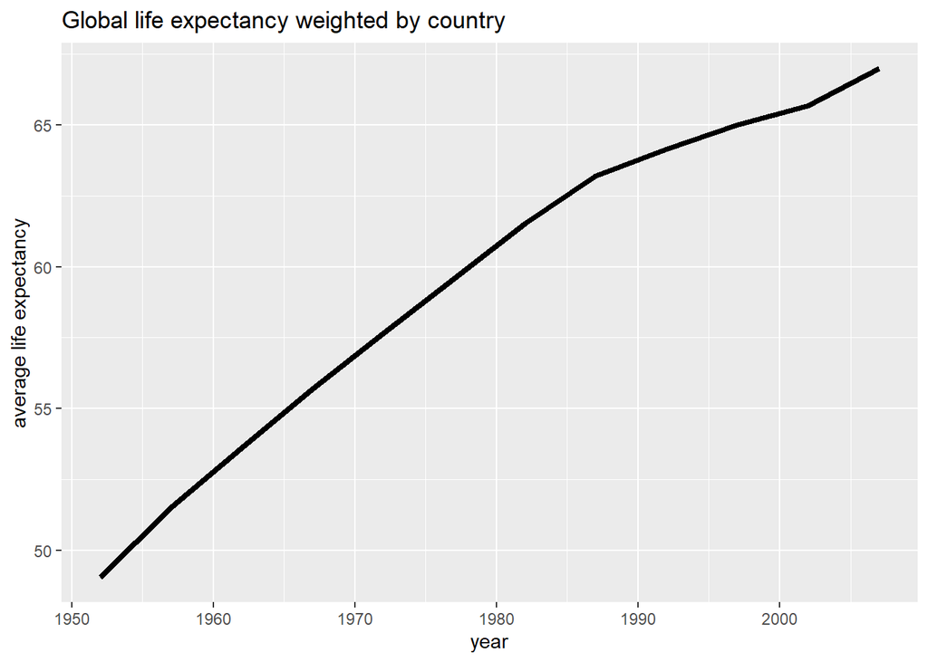

```r
gapminder %>%
  group_by(year) %>%
  summarize(avg_lifeExp_c=mean(lifeExp)) %>%
  ggplot(aes(x=year, y=avg_lifeExp_c))+geom_line(size=1.5) +
  ylab("average life expectancy") +
  ggtitle("Global life expectancy weighted by country")
```

We can see that the ‘kink’ around the early 1960s that was present on the first plot is smoothed out. This suggests that some countries had a population boom or drop in life expectancy around that time.

Let’s further group our data by continent to track down that country/those countries:

### Figure 7

```r
lifeExp_cont <- gapminder %>%
  group_by(year, continent) %>%
  summarize(avg_lifeExp=weighted.mean(lifeExp, pop))

datatable(lifeExp_cont, caption="Average life expectancy by continent")
```

|  | year | continent | avg_lifeExp |
| --- | --- | --- | --- |
| 1 | 1952 | Africa | 38.7997279750475 |
| 2 | 1952 | Americas | 60.2359897329338 |
| 3 | 1952 | Asia | 42.9411433815645 |
| 4 | 1952 | Europe | 64.9053961792257 |
| 5 | 1952 | Oceania | 69.1704018414364 |
| 6 | 1957 | Africa | 40.9403052180766 |
| 7 | 1957 | Americas | 62.0180618513162 |
| 8 | 1957 | Asia | 47.2883493522573 |
| 9 | 1957 | Europe | 66.8936447278967 |
| 10 | 1957 | Oceania | 70.3169319373946 |

[output cut: 50 more lines]

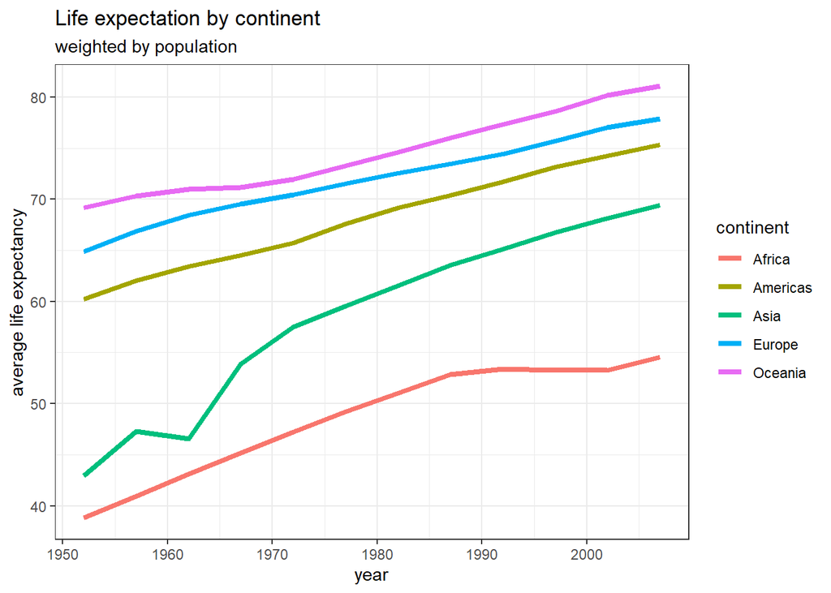

```r
lifeExp_cont %>%
  ggplot(aes(x=year, y=avg_lifeExp, color=continent)) +
  geom_line(size=1.5) +
  theme_bw() +
  ylab("average life expectancy") +
  ggtitle("Life expectation by continent", subtitle="weighted by population")
```

Based on this, it’s likely that this occurred in some Asian country/countries. Read on to the next task, where we will continue our investigative work to speculate what may have happened!

## Task Option 6, Attempt 1

*Find countries with interesting stories. Open-ended and, therefore, hard. Promising but unsuccessful attempts are encouraged. This will generate interesting questions to follow up on in class.*

Let’s return to the plot from Task 4, where we found that the average life expectancy (weighted by population) stagnated around 1960 for Asia, suggesting a population boom and/or drop in life expectancy. The goal in this task will be to pinpoint the country or countries involved, and compare the data we unearth to historical events to see how well our conclusions hold up.

Let’s start by determining population growth per Asian country from the 1950s to 1960s, the time during which this trend is observed:

### Figure 8

```r
pop_growth <- gapminder %>%
  filter(continent=="Asia" & year %in% c(1952, 1957, 1962, 1967)) %>%
  group_by(country) %>%
  arrange(country, year) %>%
  mutate(growth=pop-lag(pop)) %>%
  drop_na() %>%
  arrange(desc(growth))

pop_growth %>%
  select(country, year, pop, growth) %>%
  datatable(caption="Population growth of Asian countries")
```

|  | country | year | pop | growth |
| --- | --- | --- | --- | --- |
| 1 | China | 1967 | 754550000 | 88780000 |
| 2 | China | 1957 | 637408000 | 81144473 |
| 3 | India | 1967 | 506000000 | 52000000 |
| 4 | India | 1962 | 454000000 | 45000000 |
| 5 | India | 1957 | 409000000 | 37000000 |
| 6 | China | 1962 | 665770000 | 28362000 |
| 7 | Indonesia | 1967 | 109343000 | 10315000 |
| 8 | Indonesia | 1962 | 99028000 | 8904000 |
| 9 | Indonesia | 1957 | 90124000 | 8072000 |
| 10 | Pakistan | 1967 | 60641899 | 7541228 |

[output cut: 89 more lines]

China and India led the board in population growth between 1955-1965. What are the life expectancy plots for the two countries during this timeframe?

### Figure 9

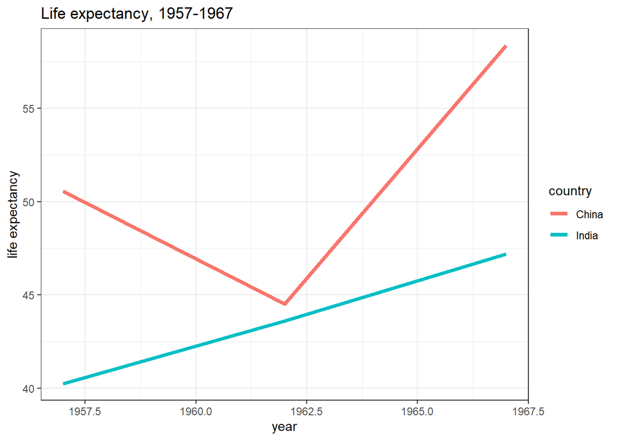

```r
pop_growth %>%
  filter(country %in% c("China", "India")) %>%
  ggplot(aes(x=year, y=lifeExp)) +
  geom_line(aes(color=country), size=1.5) +
  theme_bw() +
  ylab("life expectancy") +
  ggtitle("Life expectancy, 1957-1967")
```

The life expectancy for India increases, but China’s actually decreases. It seems we’ve found our country. In fact, here’s the global data with China separated out:

### Figure 10

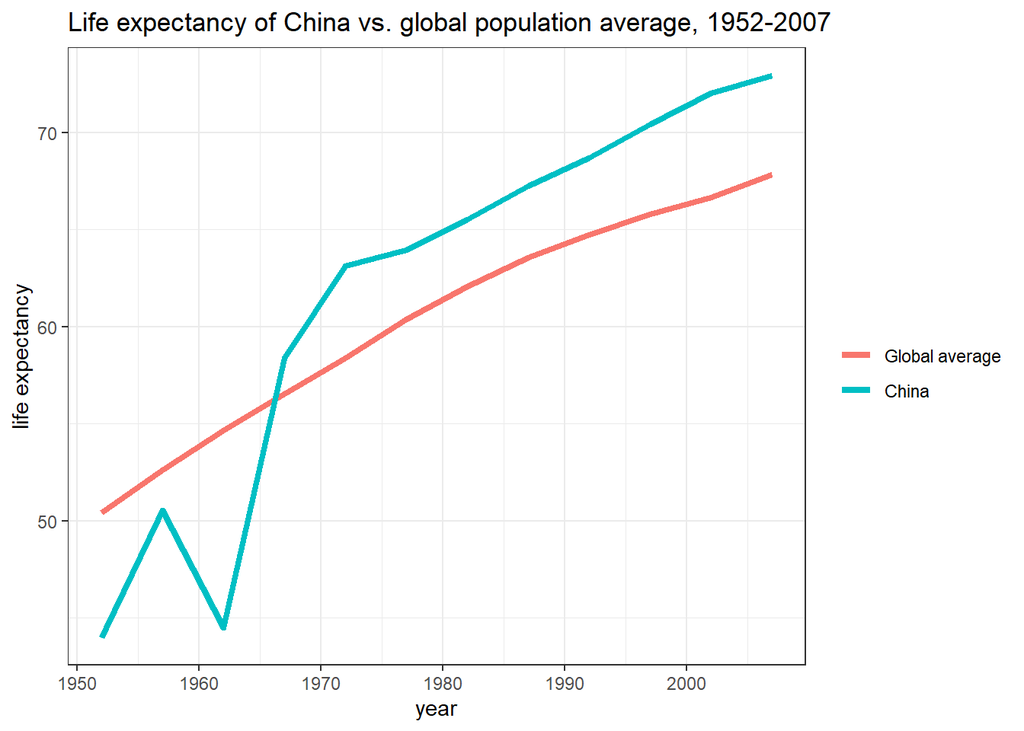

```r
gapminder %>%
  group_by(ischina=country=="China", year) %>%
  summarize(avg_lifeExp=weighted.mean(lifeExp, pop)) %>%
  ggplot(aes(x=year, y=avg_lifeExp, color=ischina))+geom_line(size=1.5) + theme_bw() +
  ggtitle("Life expectancy of China vs. global population average, 1952-2007") +
  ylab("life expectancy") + scale_color_discrete("", labels=c("Global average", "China"))
```

Without China’s contribution to the global average, the shape of the trendline actually smooths out completely!

Let’s take a look at the spread of Asian population growth, normalized by percentage, over the 1950s and 1960s:

### Figure 11

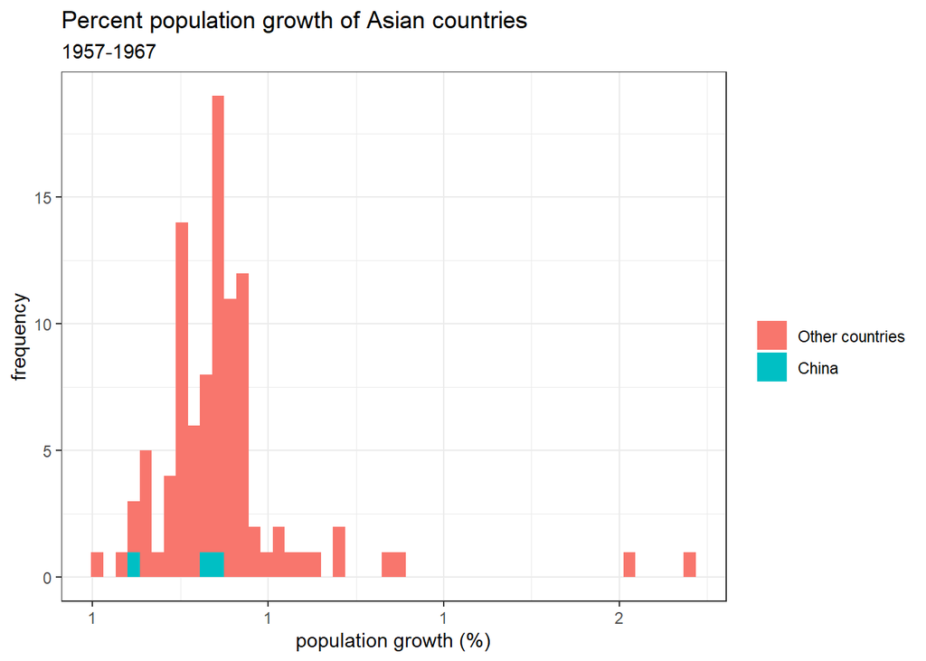

```r
pop_growth %>%
  mutate(percent=pop/(pop-growth)) %>%
  ggplot(aes(x=percent, fill=country=="China"))+
  geom_histogram(bins=50)+scale_x_continuous(labels=comma_format()) +
  theme_bw() +
  xlab("population growth (%)") +
  ylab("frequency") +
  scale_fill_discrete("", labels=c("Other countries", "China")) +
  ggtitle("Percent population growth of Asian countries", subtitle="1957-1967")
```

Here we can see that China’s population growth was actually fairly normal for a population of that size. Maybe even a little low.

How does China’s population growth and life expectancy look over 50 years?

### Figure 12

```r
china_data <- gapminder %>%
  filter(country=="China") %>%
  arrange(year) %>%
  mutate(growth=pop-lag(pop), percent=pop/(pop-growth)) %>%
  drop_na()

kable(china_data, caption="China's population growth, 1957-2007")
```

China’s population growth, 1957-2007

| country | continent | year | lifeExp | pop | gdpPercap | growth | percent |
| --- | --- | --- | --- | --- | --- | --- | --- |
| China | Asia | 1957 | 50.54896 | 637408000 | 575.9870 | 81144473 | 1.145874 |
| China | Asia | 1962 | 44.50136 | 665770000 | 487.6740 | 28362000 | 1.044496 |
| China | Asia | 1967 | 58.38112 | 754550000 | 612.7057 | 88780000 | 1.133349 |
| China | Asia | 1972 | 63.11888 | 862030000 | 676.9001 | 107480000 | 1.142443 |
| China | Asia | 1977 | 63.96736 | 943455000 | 741.2375 | 81425000 | 1.094457 |
| China | Asia | 1982 | 65.52500 | 1000281000 | 962.4214 | 56826000 | 1.060232 |
| China | Asia | 1987 | 67.27400 | 1084035000 | 1378.9040 | 83754000 | 1.083730 |
| China | Asia | 1992 | 68.69000 | 1164970000 | 1655.7842 | 80935000 | 1.074661 |
| China | Asia | 1997 | 70.42600 | 1230075000 | 2289.2341 | 65105000 | 1.055886 |
| China | Asia | 2002 | 72.02800 | 1280400000 | 3119.2809 | 50325000 | 1.040912 |
| China | Asia | 2007 | 72.96100 | 1318683096 | 4959.1149 | 38283096 | 1.029899 |

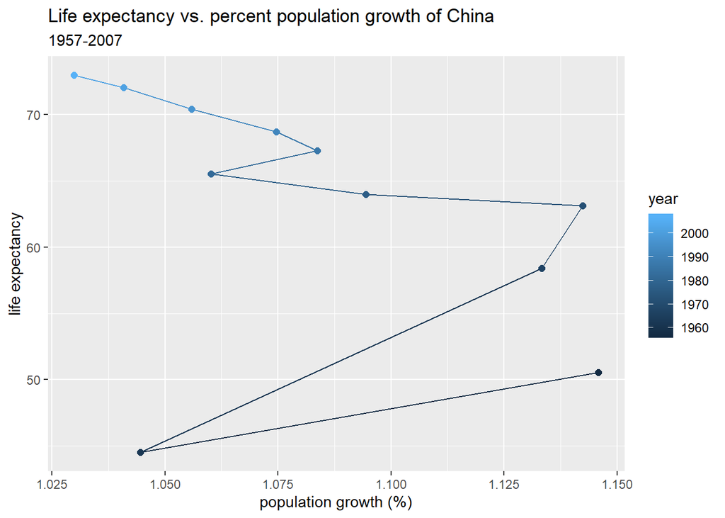

```r
china_data %>%
  ggplot(aes(x=percent,y=lifeExp,color=year)) +
  geom_path() +
  geom_point(size=2) +
  ylab("life expectancy") + xlab("population growth (%)") +
  ggtitle("Life expectancy vs. percent population growth of China", subtitle="1957-2007")
```

It seems something drastic occurred between 1957 and 1962, and a second, less impactful event about a decade later. I already have a strong suspicion what happened during that time period, but let’s continue our data exploration and see what else we can unearth.

How did China’s life expectancy change compared to other Asian countries during this time period?

### Figure 13

[figure not shown]

```r
pop_growth %>%
  ggplot(aes(x=year, y=lifeExp, group=country, color=country=="China")) +
  geom_line(alpha=0.5, size=1.5) +
  theme_bw() +
  ylab("life expectancy") +
  scale_color_discrete("", labels=c("Global average", "China")) +
  ggtitle("Life expectancy, 1957-1967", subtitle="China vs global average")
```

While other countries exhibited a steady increase in life expectancy, China’s actually dropped during the early 1960s.

Finally, let’s look at GDP per capita:

### Figure 14

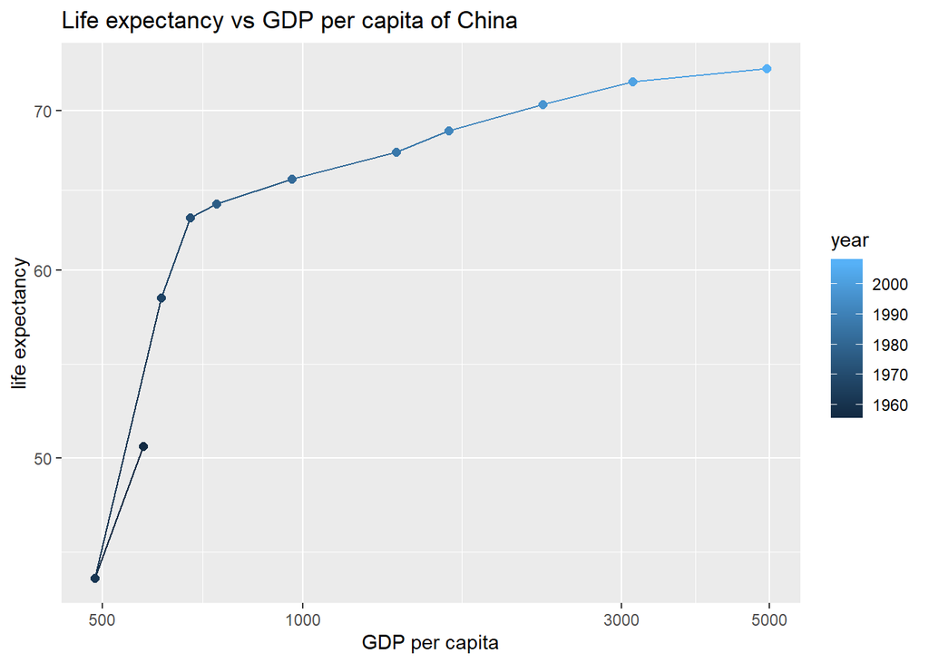

```r
china_data %>%
  ggplot(aes(x=gdpPercap,y=lifeExp, color=year)) +
  geom_path() +
  scale_x_log10() +
  scale_y_log10() +
  geom_point(size=2) +
  ylab("life expectancy") +
  xlab("GDP per capita") +
  ggtitle("Life expectancy vs GDP per capita of China")
```

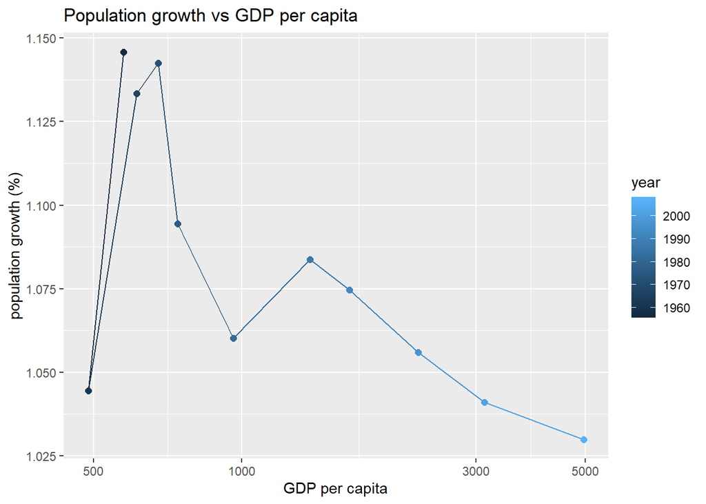

```r
china_data %>%
  ggplot(aes(y=percent,x=gdpPercap, color=year)) +
  geom_path() +
  scale_x_log10() +
  geom_point(size=2) +
  ylab("population growth (%)") +
  xlab("GDP per capita") +
  ggtitle("Population growth vs GDP per capita")
```

The data in all of these graphs points to the same conclusion: something happened around the 1960s that walloped China’s population growth, life expectancy and GDP per capita.

So what was the event I was alluding to? I believe these trends were caused by the [Great Leap Forward](https://en.wikipedia.org/wiki/Great_Leap_Forward) (1958-1962). This was a movement to convert China’s then agrarian economy to socialism, which backfired with devastating results for the populace (namely, the [Great Chinese Famine](https://en.wikipedia.org/wiki/Great_Chinese_Famine)).

It’s pretty amazing that the fallout of one country’s history is visible on a global scale! Just how does China’s population compare to the rest of the world’s?

### Figure 15

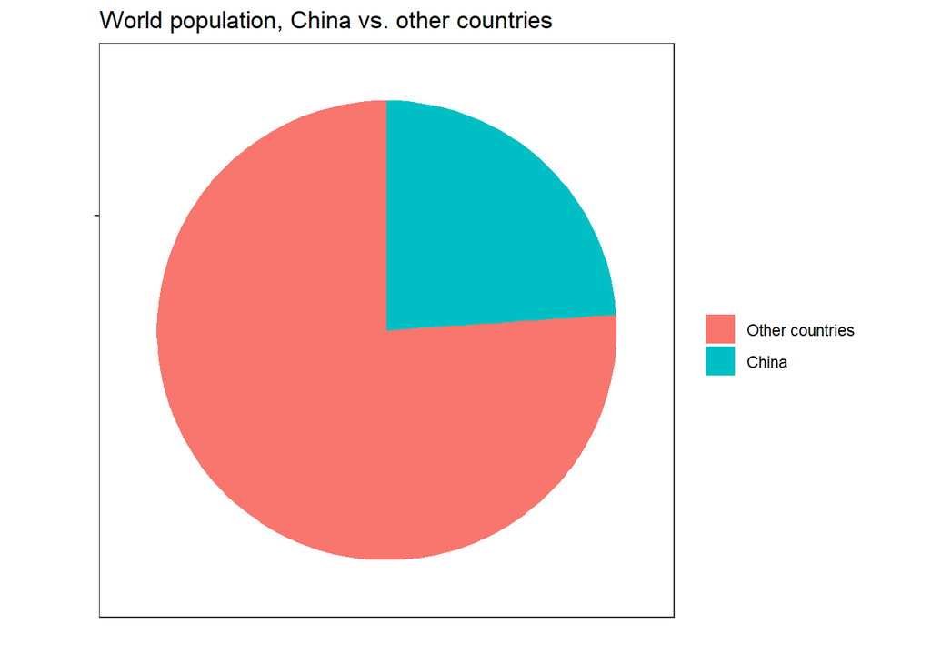

```r
gapminder %>%
  filter(year==1957) %>%
  group_by(country=="China") %>%
  ggplot(aes(x="", y=pop, fill=country=="China")) +
  geom_bar(stat="identity") +
  coord_polar("y", start=0) +
  scale_y_continuous(labels=NULL) +
  xlab("") + ylab("") +
  theme_bw() +
  theme(panel.grid.major = element_blank(), panel.grid.minor = element_blank()) +
  scale_fill_discrete("", labels=c("Other countries", "China")) +
  ggtitle("World population, China vs. other countries")
```

In 1957, China constituted nearly a quarter of the world population. It’s no wonder that these drastic changes left a mark in global data.

## Task Option 6, Attempt 2

This section will be shorter as it showcases essentially the same steps as above.

Let’s change gears to GDP per capita again. Here is a plot of GDP per capita over the years, weighted by country instead of population:

### Figure 16

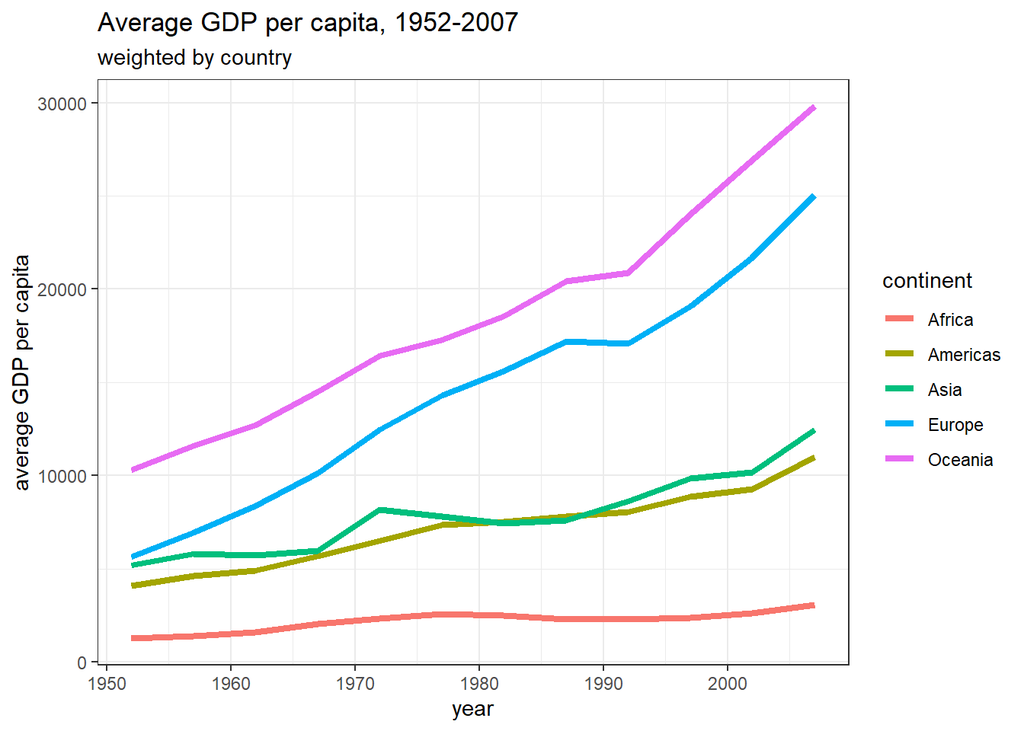

```r
gapminder %>%
  group_by(continent, year) %>%
  summarize(avggdp=mean(gdpPercap)) %>%
  ggplot(aes(x=year, y=avggdp, color=continent)) + geom_line(size=1.5) + theme_bw() +
  ggtitle("Average GDP per capita, 1952-2007", subtitle="weighted by country") +
  ylab("average GDP per capita")
```

We can see a spike in Asia’s average GDP per capita, followed by a slight fall. Since the plot is weighted by country, we know it’s likely one with a smaller population.

### Figure 17

```r
gdp_asia <- gapminder %>%
  filter(continent=="Asia" & year>=1962 & year<=1987) %>%
  arrange(pop)

datatable(gdp_asia, caption="GDP per capita of Asian countries, 1962-1987")
```

|  | country | continent | year | lifeExp | pop | gdpPercap |
| --- | --- | --- | --- | --- | --- | --- |
| 1 | Bahrain | Asia | 1962 | 56.923 | 171863 | 12753.27514 |
| 2 | Bahrain | Asia | 1967 | 59.923 | 202182 | 14804.6727 |
| 3 | Bahrain | Asia | 1972 | 63.3 | 230800 | 18268.65839 |
| 4 | Bahrain | Asia | 1977 | 65.593 | 297410 | 19340.10196 |
| 5 | Kuwait | Asia | 1962 | 60.47 | 358266 | 95458.11176 |
| 6 | Bahrain | Asia | 1982 | 69.052 | 377967 | 19211.14731 |
| 7 | Bahrain | Asia | 1987 | 70.75 | 454612 | 18524.02406 |
| 8 | Kuwait | Asia | 1967 | 64.624 | 575003 | 80894.88326 |
| 9 | Oman | Asia | 1962 | 43.165 | 628164 | 2924.638113 |
| 10 | Oman | Asia | 1967 | 46.988 | 714775 | 4720.942687 |

[output cut: 188 more lines]

[figure not shown]

```r
gdp_asia %>%
  ggplot(aes(x=year,y=gdpPercap, group=country, color=country=="Kuwait")) +
  geom_line(size=1.5, alpha=1/3) +
  theme_bw() +
  scale_color_discrete("", labels=c("Other countries", "Kuwait")) +
  ggtitle("GDP per capita of Asian countries, 1967-1987") + ylab("GDP per capita")
```

So I cheated a little and referred back to my output from Task Option 2, and guessed that the country contributing most to this trend seems to be Kuwait. However, an online search reveals the 1970s to be Kuwait’s golden era, with immense economic growth due to oil in the 1970s. How to resolve this discrepancy?

A closer look at the tibble above reveals another possible lead: population. Let’s plot Kuwait’s GDP per capita vs. population growth.

### Figure 18

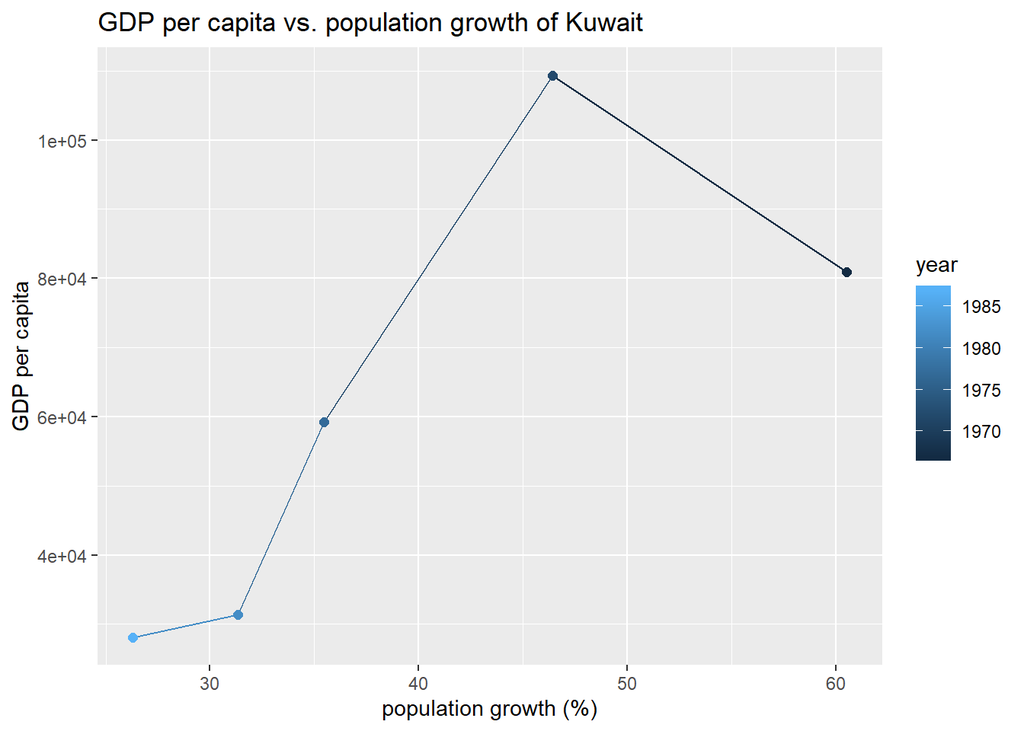

```r
gdp_asia %>%
  filter(country=="Kuwait") %>%
  arrange(year) %>%
  mutate(growth=(pop-lag(pop))/lag(pop)*100) %>%
  drop_na() %>%
  ggplot(aes(x=growth,y=gdpPercap, group=country, color=year)) +
  geom_path() +
  geom_point(size=2) +
  ylab("GDP per capita") +
  xlab("population growth (%)") +
  ggtitle("GDP per capita vs. population growth of Kuwait")
```

This graph shows that at the same time that Kuwait’s population growth slowed, its GDP per capita also decreased. This is contrary to my initial hypothesis that the population increased faster than GDP, leading to a decreased GDP per capita.

After some more reading, I can only speculate that since Kuwait’s economic boom was largely oil-based, the seemingly counterintuitive dip in its GDP per capita may be related to the [1973 oil crisis](https://en.wikipedia.org/wiki/1973_oil_crisis). In fact, referring back to Task 2, Kuwait had actually led Asia and the world in GDP per capita up until this point.

## The End

Thank you for reviewing my assignment. I hope you had as good a time looking at my work as I did creating it!